# RDB Catch and Effort Overview North Atlantic

RCG ISSG Regional overviews

17 marzo, 2022

[figure not shown]

**RCG Multiannual overviews**

The present Catch and Effort Overview displays summary information on the commercial landings (CL) and commercial effort (CE) statistics included in the Regional Data Base (RDB), which is used to store detailed commercial fisheries and sampling data.

Before the subgroup on Catch, effort and sampling overviews was set up, the different RCGs conducted data analysis and overviews separately with minimal exchange, resulting in redundancies and efficiency loss. Furthermore, a substantial part of the work was being carried out during the RCG meetings themselves and so not readily available to inform RCG preparation and meeting discussions. This group was established to streamline and facilitate the work on the fisheries and sampling data of the MS and prepare data overviews in advance of the RCG meetings.

However, it has been recognised for many years that there is a need to have a new version of the RDB which would also store details about how the sampling was performed and enable statistical estimations to be made.

In fact, the current Regional Data Base stores the commercial catch and sample data at detailed level, and here the data format and estimations does not support statistical estimations, even though most of the countries’ sampling are not done in a statistical way the countries never used the RDB for raising/estimating their data. The countries have raised/estimated the data nationally at the institutes and uploaded the data to InterCatch for the stock assessment Expert Groups. That means the stock assessment EG have no information of how the data have been raised/estimated until the data are uploaded into InterCatch, from that point and through the international raising the data and processes are fully documented. InterCatch does neither support statistical estimations. It has therefore been requested to write specifications for a new version of the RDB, which have been given the name ‘Regional DataBase and Estimation System’, RDBES, to make it more obvious that the major part of the RDB is the estimation part.

## Overall fleet evolution (All RCGs)

### Number of vessels

Number of vessels by flag country in the EU vessel register.

| rowname | BEL | DEU | DNK | ESP | EST | FIN | FRA | GBR | IRL | LTU | LVA | NLD | POL | PRT | SWE |
| --- | --- | --- | --- | --- | --- | --- | --- | --- | --- | --- | --- | --- | --- | --- | --- |
| 2016 | 76 | 1,442 | 2,332 | 9,395 | 1,538 | 2,661 | 6,914 | 5,517 | 2,110 | 124 | 290 | 822 | 875 | 3,681 | 1,314 |
| 2017 | 72 | 1,410 | 2,240 | 9,310 | 1,557 | 3,016 | 6,845 | 5,586 | 2,091 | 125 | 263 | 836 | 843 | 3,461 | 1,269 |
| 2018 | 71 | 1,365 | 2,180 | 9,145 | 1,595 | 3,141 | 6,495 | 5,656 | 1,993 | 125 | 247 | 841 | 834 | 3,615 | 1,225 |
| 2019 | 68 | 1,318 | 2,104 | 8,973 | 1,662 | 3,157 | 6,336 | 5,694 | 2,003 | 124 | 235 | 831 | 827 | 3,490 | 1,166 |
| 2020 | 68 | 1,290 | 2,060 | 8,882 | 1,571 | 3,120 | 6,169 | 5,643 | 1,990 | 119 | 232 | 833 | 826 | 3,651 | 1,080 |

### Power

Power (`1000*`kW) by flag country in the EU vessel register.

| rowname | BEL | DEU | DNK | ESP | EST | FIN | FRA | GBR | IRL | LTU | LVA | NLD | POL | PRT | SWE |
| --- | --- | --- | --- | --- | --- | --- | --- | --- | --- | --- | --- | --- | --- | --- | --- |
| 2016 | 45.3 | 140.9 | 218.6 | 797.1 | 44.3 | 140.2 | 999.1 | 725.3 | 187.8 | 49.7 | 32.6 | 302.6 | 81.5 | 262.7 | 162.2 |
| 2017 | 45.1 | 139.8 | 208.1 | 791.1 | 45.5 | 151.3 | 1,003.8 | 727.7 | 190.1 | 47.6 | 42.3 | 308.7 | 83.0 | 247.5 | 158.0 |
| 2018 | 45.1 | 131.9 | 204.8 | 784.3 | 45.0 | 156.2 | 968.9 | 725.4 | 187.9 | 46.0 | 33.7 | 315.3 | 76.3 | 251.9 | 147.7 |
| 2019 | 42.7 | 126.3 | 213.6 | 778.5 | 46.1 | 155.4 | 964.5 | 733.7 | 188.5 | 43.2 | 32.6 | 304.1 | 80.2 | 240.5 | 145.0 |
| 2020 | 42.8 | 123.9 | 202.3 | 777.3 | 39.8 | 154.0 | 949.8 | 741.6 | 190.3 | 41.7 | 17.4 | 301.6 | 80.2 | 260.3 | 132.5 |

### Gross tonnage

Gross Tonnage (`1000*`GT) by flag country in the EU vessel register.

| rowname | BEL | DEU | DNK | ESP | EST | FIN | FRA | GBR | IRL | LTU | LVA | NLD | POL | PRT | SWE |
| --- | --- | --- | --- | --- | --- | --- | --- | --- | --- | --- | --- | --- | --- | --- | --- |
| 2016 | 14.1 | 63.9 | 65.8 | 340.9 | 13.5 | 10.5 | 171.9 | 179.9 | 61.2 | 44.8 | 17.7 | 126.9 | 34.2 | 71.5 | 29.4 |
| 2017 | 13.9 | 63.7 | 67.1 | 337.4 | 14.3 | 11.0 | 173.4 | 180.2 | 62.7 | 40.8 | 26.0 | 130.9 | 34.9 | 65.4 | 27.9 |
| 2018 | 13.7 | 62.3 | 68.0 | 334.3 | 14.1 | 11.2 | 174.2 | 181.2 | 63.3 | 40.2 | 19.5 | 133.2 | 27.6 | 62.9 | 25.3 |
| 2019 | 12.9 | 55.2 | 74.0 | 331.6 | 15.5 | 10.7 | 177.0 | 188.5 | 63.9 | 37.2 | 17.9 | 120.4 | 32.4 | 61.2 | 25.6 |
| 2020 | 12.9 | 54.8 | 68.0 | 332.6 | 12.4 | 10.6 | 171.9 | 196.7 | 65.3 | 36.2 | 6.2 | 116.0 | 32.3 | 69.5 | 22.6 |

## RDB data

The figures below are based on RDB effort (CE) and landings (CL) data.

## Effort

The annual fishing effort in number of days at sea for the North Atlantic region, is presented in figures below. The first panel (‘Days at sea Total fisheries’) gives a general idea on the annual total fishing effort by country. The following panels present the annual fishing effort distribution among the different fisheries by country, where the “Fishing activity level 5” data is grouped according to métier level 3 definition: the “Bottom trawl fisheries” include the otter and pair bottom trawls (OTB and PTB), the multi-rig otter trawl (OTT) and the beam bottom trawl (TBB); the “Pelagic trawl fisheries” include the mid-water otter trawl (OTM) and pelagic pair trawl (PTM); the “Surrounding nets fisheries” include the lampara nets (LA) and purse seine (PS); the “Seine fisheries” include the beach and boat seines (SB and SV), the fly shooting seine (SSC), anchored seine (SDN) and pair seine (SPR); the “Net fisheries” include set gillnet (GNS), driftnet (GND) and trammel net (GTR); the “Longline fisheries” include set and drifting longlines (LLS and LLD); the “Rods and lines fisheries” include the hand and pole lines (LHP and LHM) and the trolling lines (LTL); the “Dredge fisheries” include boat and hand dredges (DRB and HMD); and “Traps fisheries” include the pots and traps (FPO), the stationary uncovered pound nets (FPN) and fyke nets (FYK). Note that the presence of “blank plots” is related to single year data in a particular gear group.

### Days at sea Total fisheries

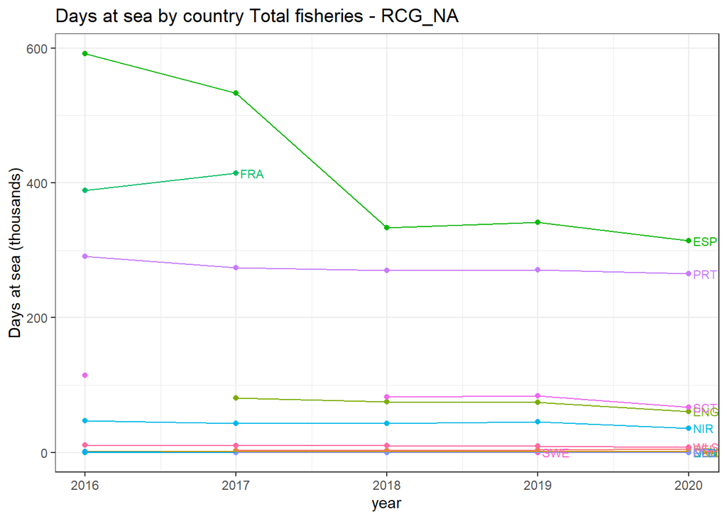

### Days at sea Bottom trawl fisheries

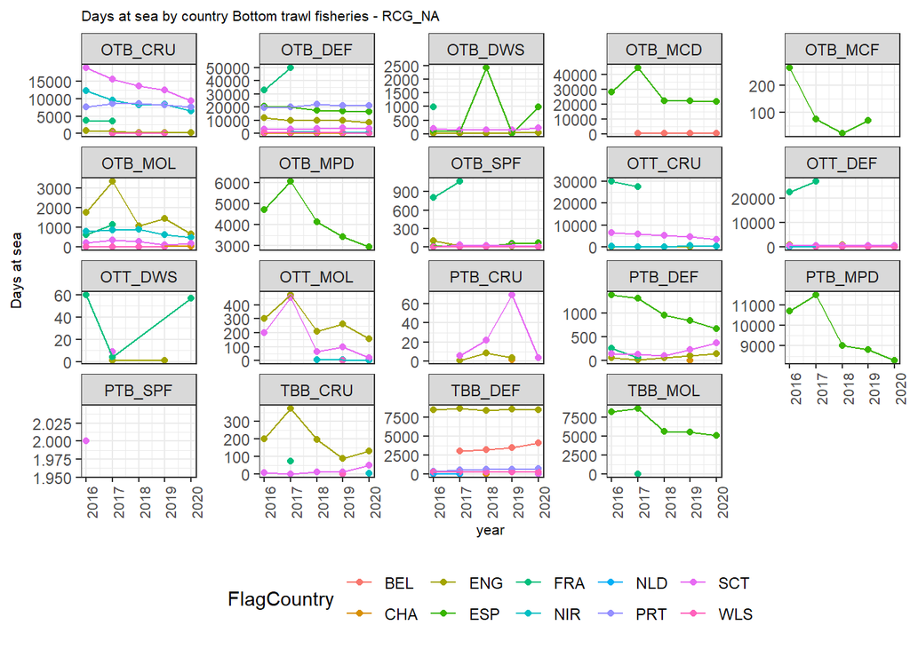

### Days at sea Pelagic trawl fisheries

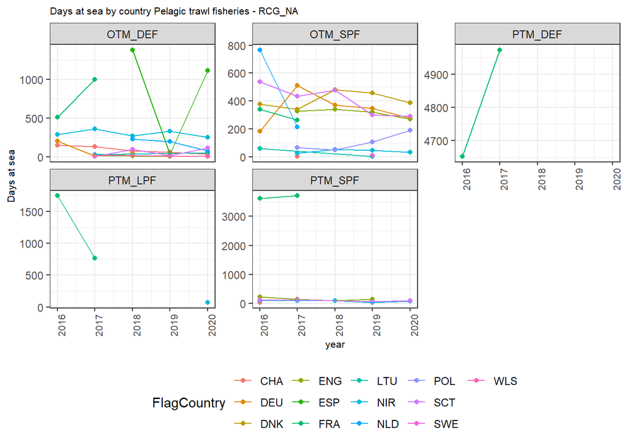

### Days at sea Surrounding nets fisheries

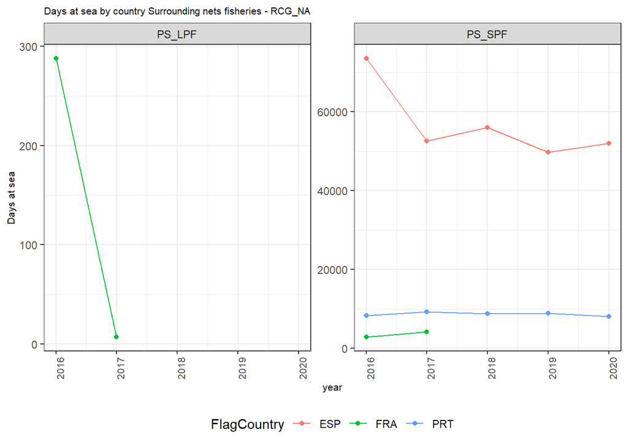

### Days at sea Seine fisheries

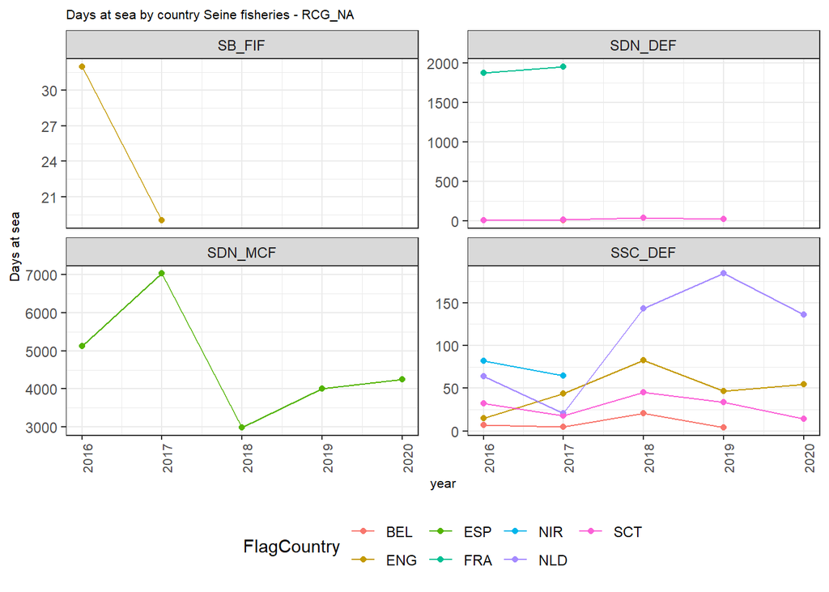

### Days at sea Net fisheries

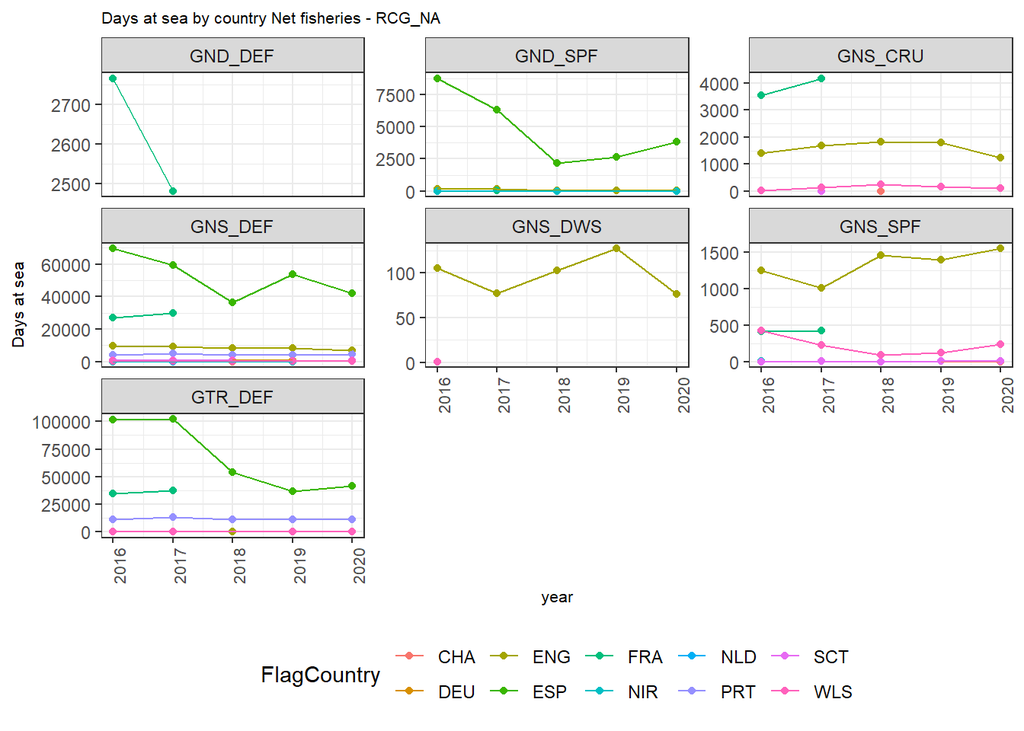

### Days at sea Longline fisheries

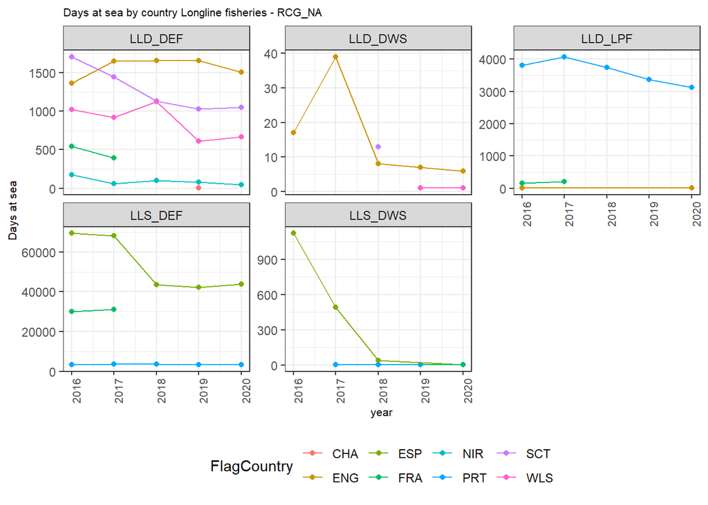

### Days at sea Rods and lines fisheries

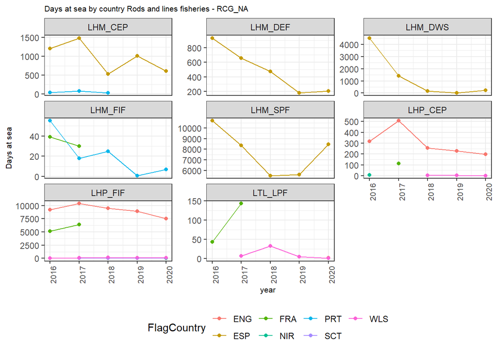

### Days at sea Dredge fisheries

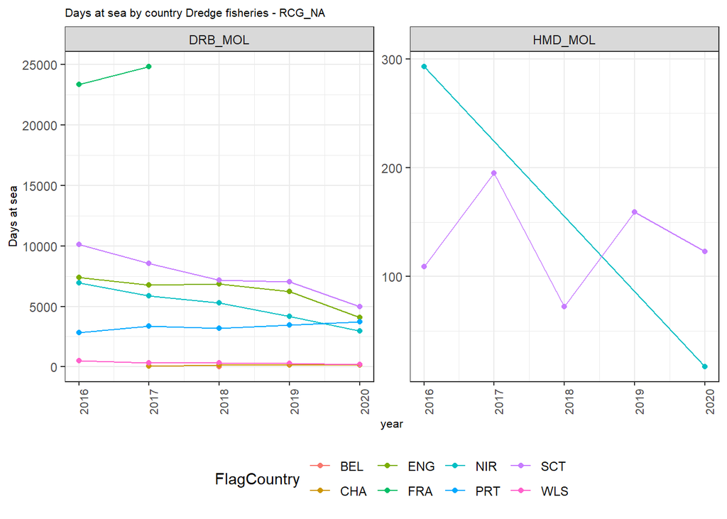

### Days at sea Traps fisheries

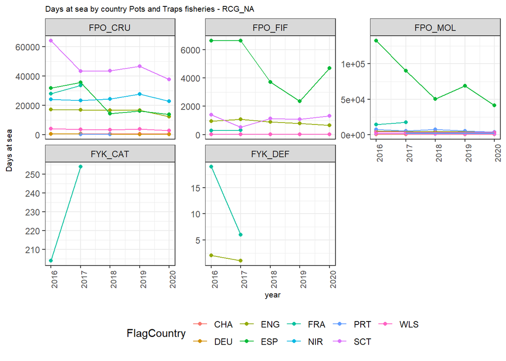

## Landings

The annual landings overview for the North Atlantic region, is presented in figures below. The first panel (‘Landings Total fisheries’) compiles the annual total landings by country. The following panels present the annual total landings from the different fisheries by country, where the “Fishing activity level 5” data is grouped according to métier level 3 definition: the “Bottom trawl fisheries” include the otter and pair bottom trawls (OTB and PTB), the multi-rig otter trawl (OTT) and the beam bottom trawl (TBB); the “Pelagic trawl fisheries” include the mid-water otter trawl (OTM) and pelagic pair trawl (PTM); the “Surrounding nets fisheries” include the lampara nets (LA) and purse seine (PS); the “Seine fisheries” include the beach and boat seines (SB and SV), the fly shooting seine (SSC), anchored seine (SDN) and pair seine (SPR); the “Net fisheries” include set gillnet (GNS), driftnet (GND) and trammel net (GTR); the “Longline fisheries” include set and drifting longlines (LLS and LLD); the “Rods and lines fisheries” include the hand and pole lines (LHP and LHM) and the trolling lines (LTL); the “Dredge fisheries” include boat and hand dredges (DRB and HMD); and “Traps fisheries” include the pots and traps (FPO), the stationary uncovered pound nets (FPN) and fyke nets (FYK). Note that the presence of “blank plots” is related to single year data in a particular gear group.

### Landings Total fisheries

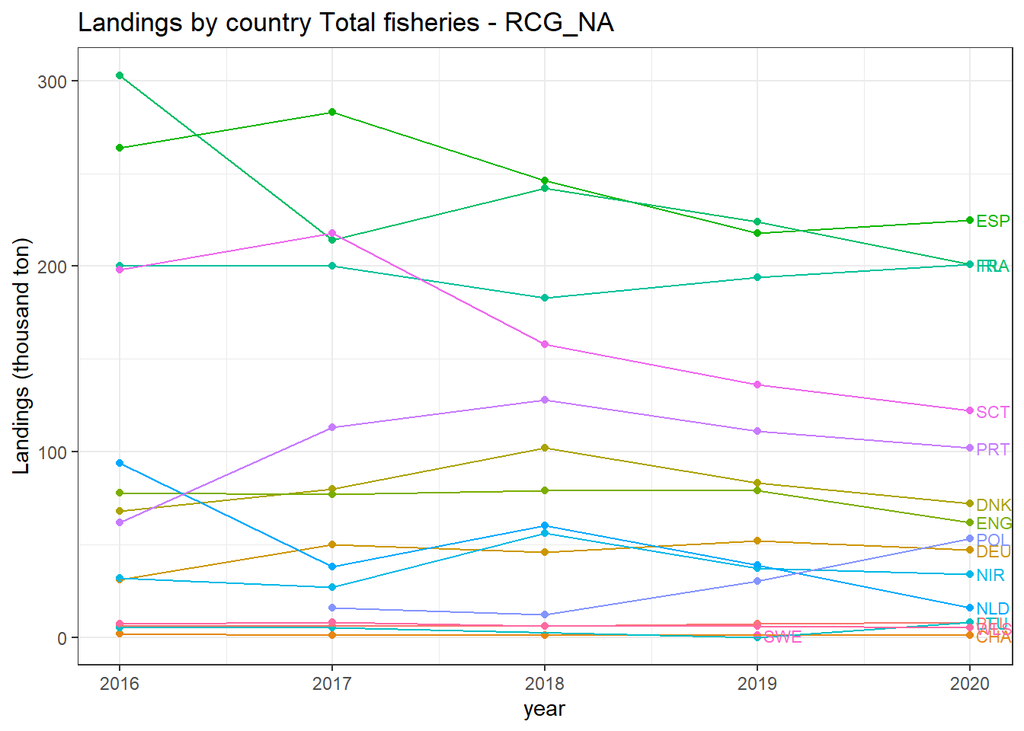

### Landings Bottom trawl fisheries

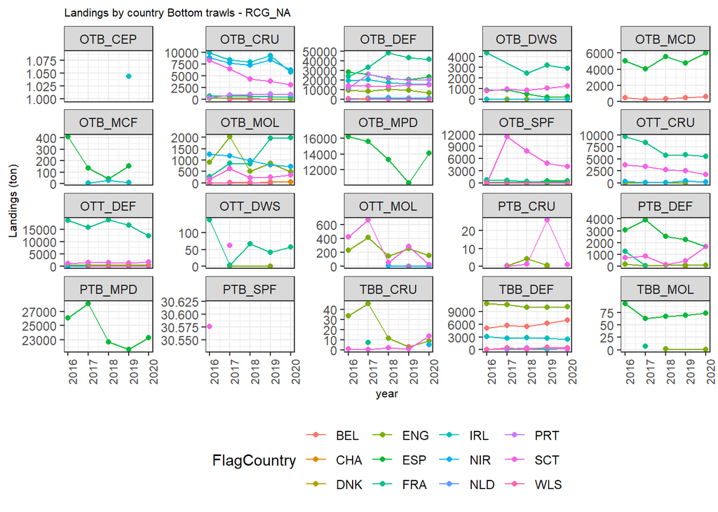

### Landings Pelagic trawl fisheries

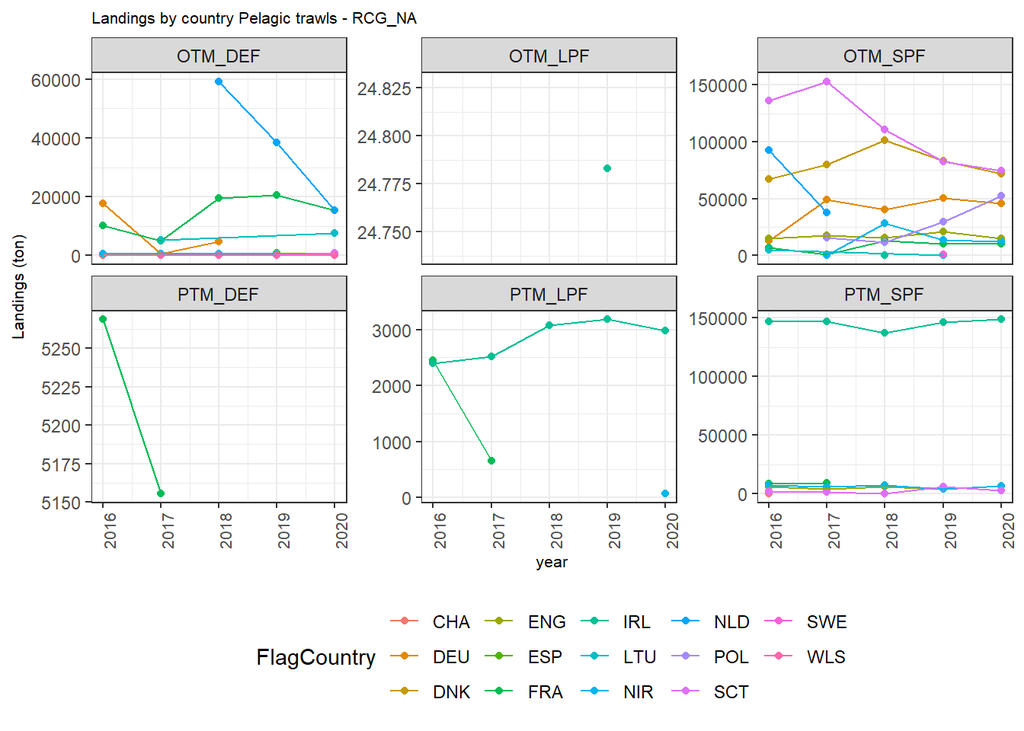

### Landings Surrounding nets fisheries

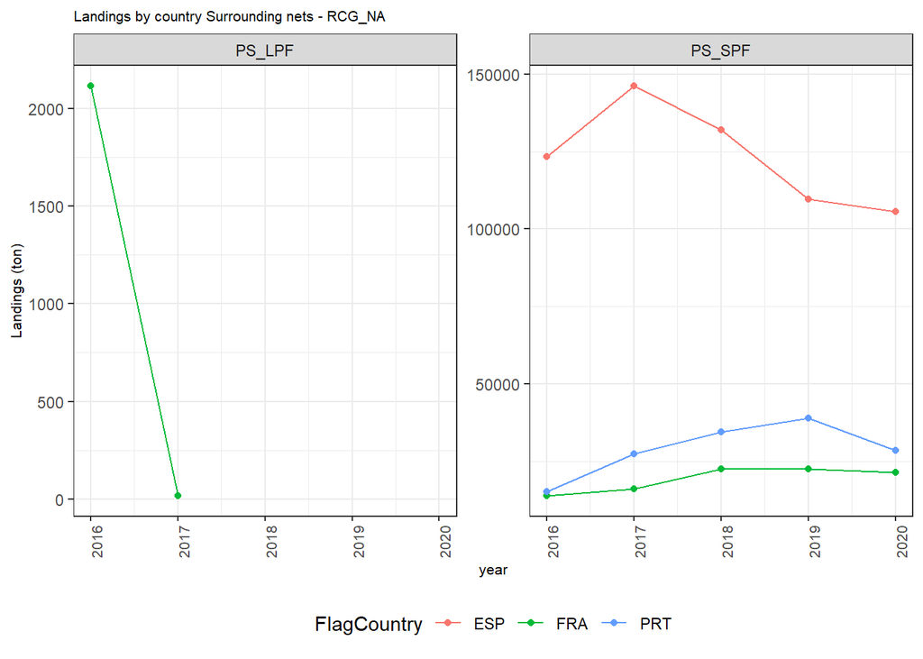

### Landings Seine fisheries

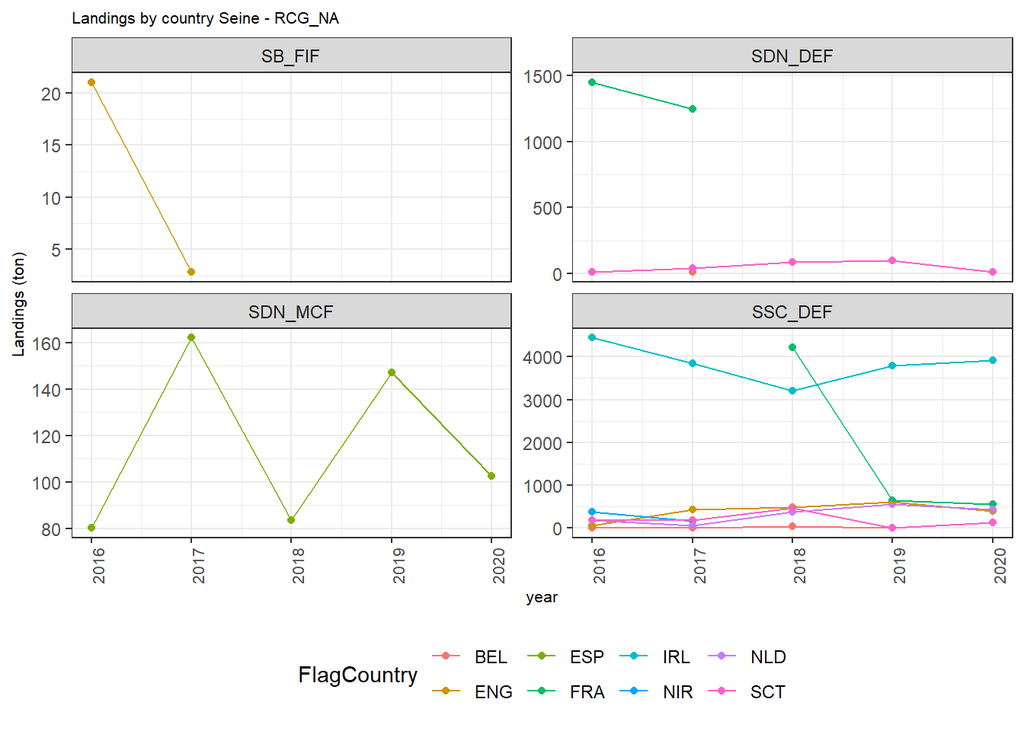

### Landings Net fisheries

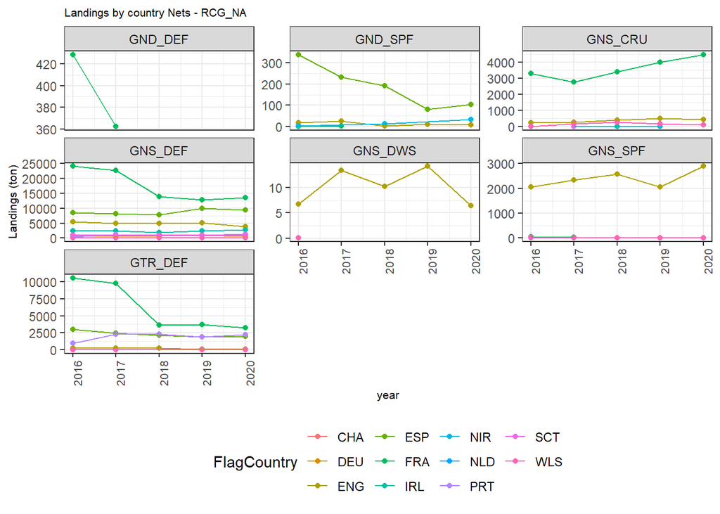

### Landings Longline fisheries

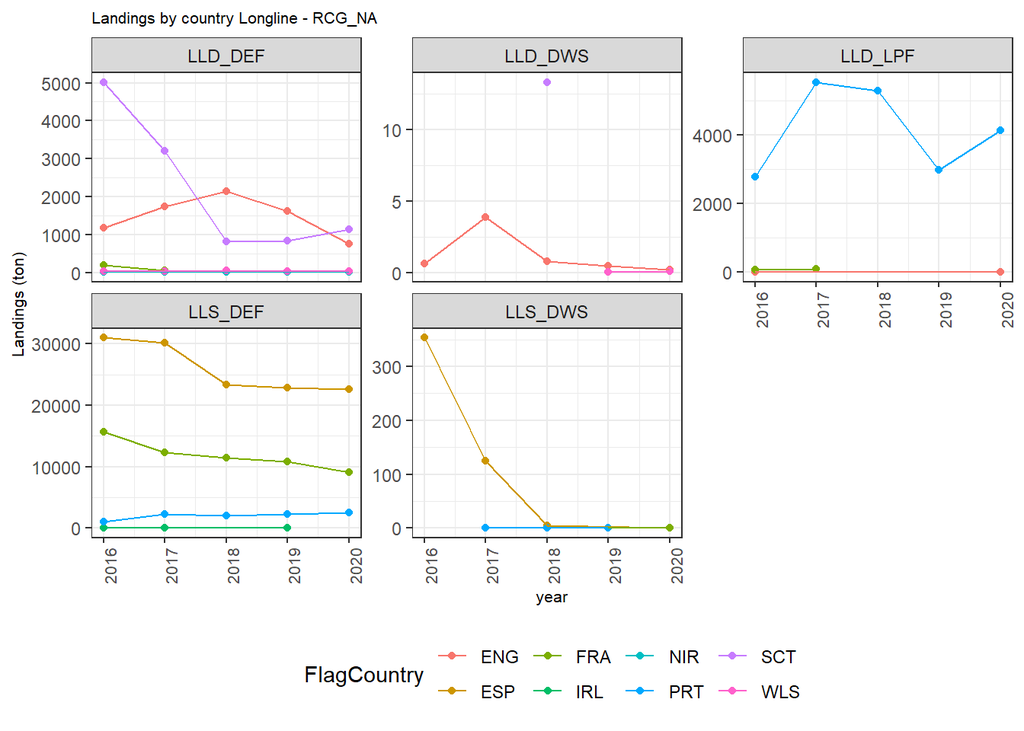

### Landings Rods and lines fisheries

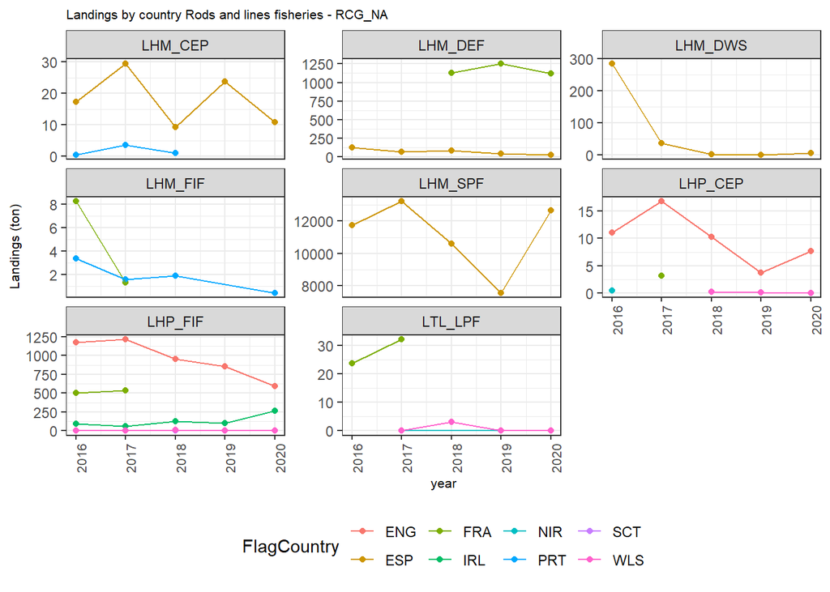

### Landings Dredge fisheries

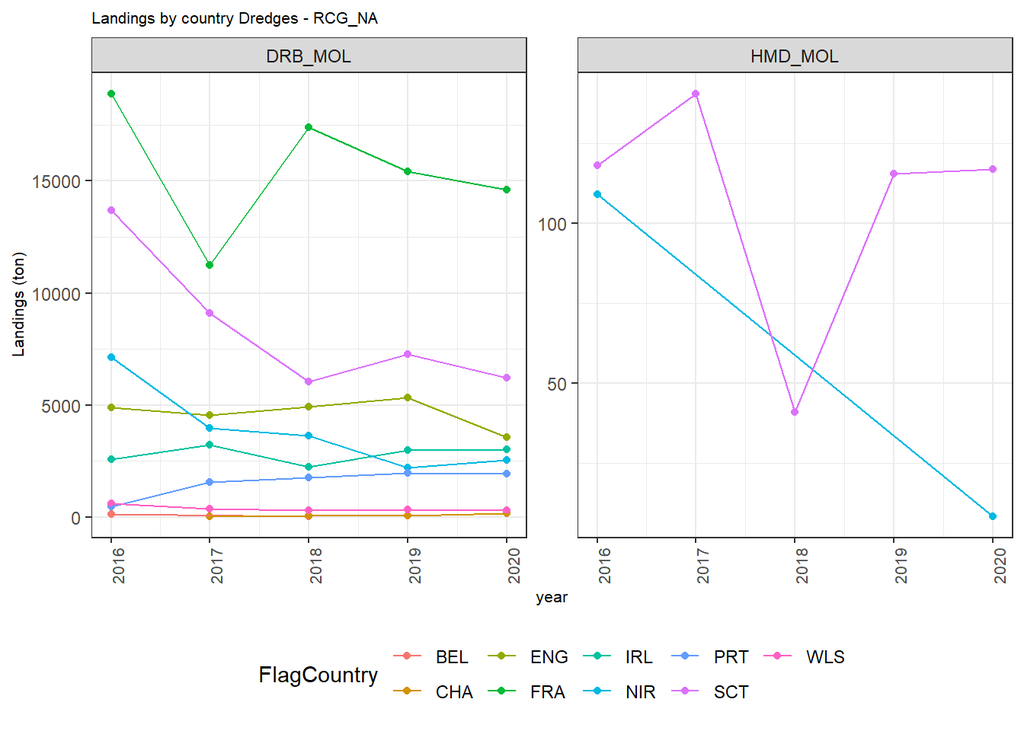

### Landings Pots and Traps fisheries

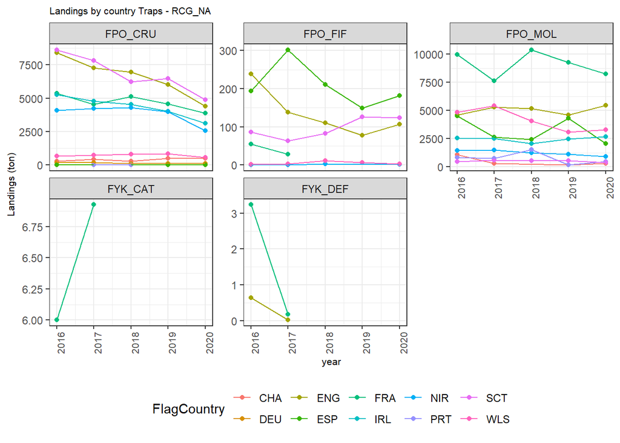

## Landings by Species

The most landed species in weight, in North Atlantic region are presented in the plots below. The first three panels show the top 10 species present in the landings of the region, using different layouts (1:lines; 2:stacked bars; 3: stacked bar proportions). The last panel presents the countries that contribute for the landings of the main landed species in weight (top 10) in the North Atlantic region.

### 1 Total landings top 10 species - line

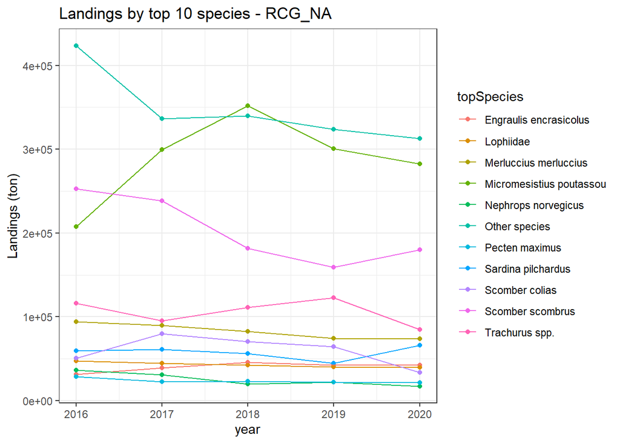

### 2 Total landings top 10 species - stacked bar

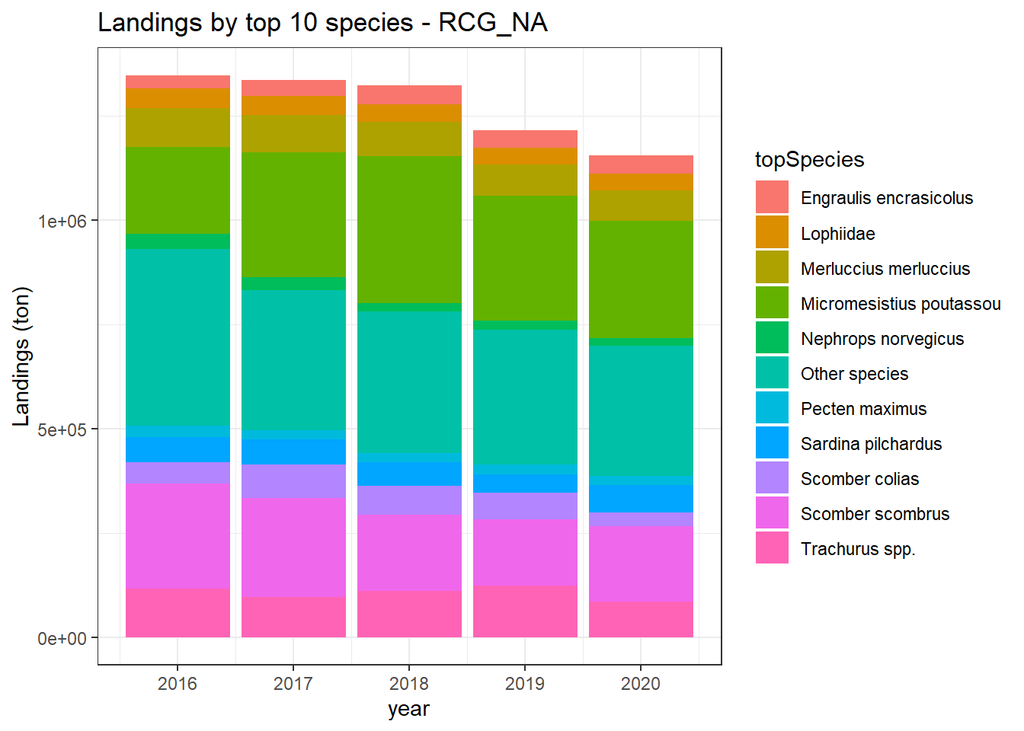

### 3 Total landings top 10 species - stacked bar pct

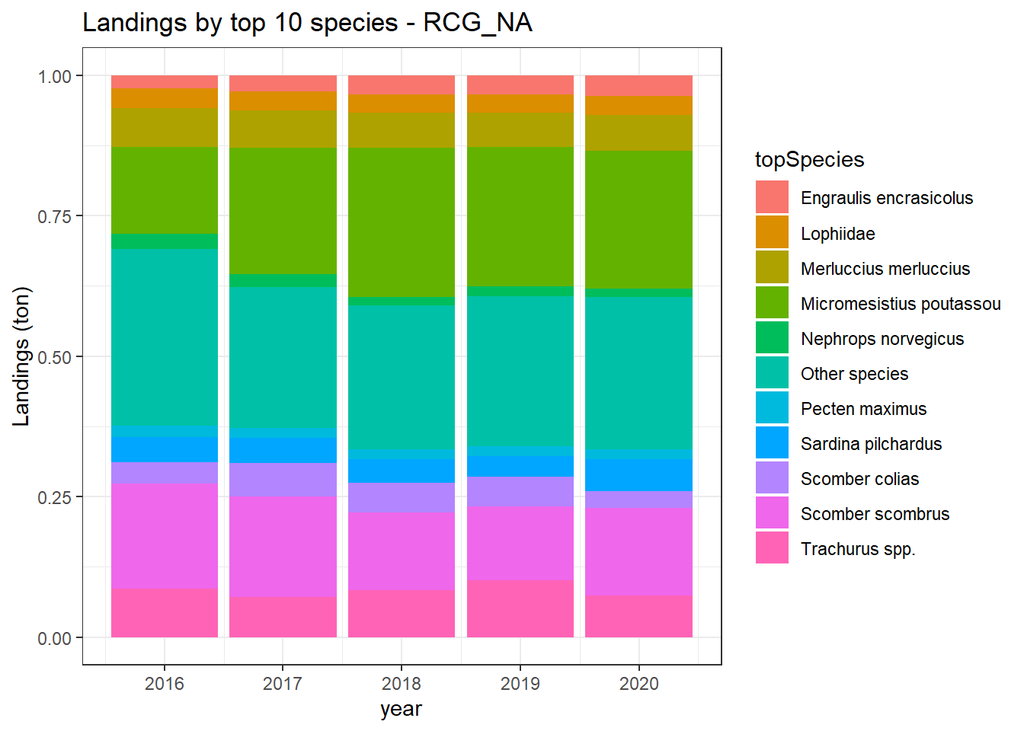

### Landings by country top 10 species - stacked bar pct

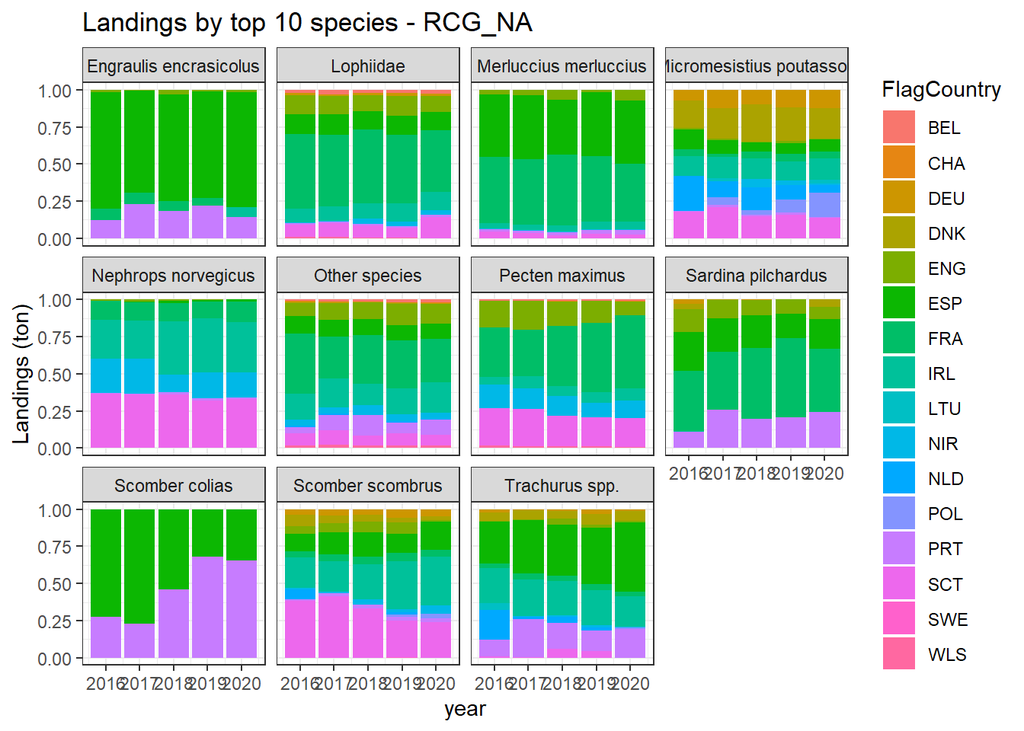

## Stock

The following chapter refers to the multiannual stocks’ distribution for North Atlantic region. This data is provided from ICES’ fishframe RDB regional database that has been working with the development and production of fisheries data.

Warning: This stock allocation represents variable stock which was adjusted by the group accordingly with procedures discussed within ICES community and therefore it does not come directly from the RDB.

### Landings by country top 5 stocks

The first table regards Top 5 stocks in Landing’s percentage incidence per country from 2016 to 2020, this stock information has been developed for this last five years scope where adjustments and definitions are being worked ever since. However, regarding this first picture, main stocks had been roughly the same and the Top 5 range only floated slightly.

|  | Year | FlagCountry | Stock | FishingGround | SpeciesDesc | Landing | Total | percent |
| --- | --- | --- | --- | --- | --- | --- | --- | --- |
| 1 | 2016 | BEL | Anglerfish. Monkfish7fgh | 7fgh | Anglerfish. Monkfish | 716 | 5729 | 13% |
| 2 | 2016 | BEL | Megrims. WoRMS 1261227fgh | 7fgh | Megrims. WoRMS 126122 | 282 | 5729 | 5% |
| 3 | 2016 | BEL | rjh.27.7afg | 7fgh | Blonde ray | 272 | 5729 | 5% |
| 4 | 2016 | BEL | sol.27.7fg | 7fgh | Common sole | 563 | 5729 | 10% |
| 5 | 2016 | BEL | sol.27.8ab | 8abde | Common sole | 288 | 5729 | 5% |
| 6 | 2016 | CHA | Edible crab7e | 7e | Edible crab | 283 | 1553 | 18% |
| 7 | 2016 | CHA | European lobster7e | 7e | European lobster | 18 | 1553 | 1% |
| 8 | 2016 | CHA | rjh.27.7e | 7e | Blonde ray | 114 | 1553 | 7% |
| 9 | 2016 | CHA | syc.27.67a-ce-j | 7e | Small-spotted catshark | 14 | 1553 | 1% |
| 10 | 2016 | CHA | Whelk7a | 7a | Whelk | 1075 | 1553 | 69% |

[output cut: 342 more lines]

### Landings by top 10 stocks

The graph refers to the Landing’s percentage incidence by Top 10 Stocks per country. The main goal of this topic is to show how stocks are allocated to each country and, also very important, there is also important to check the evolution since 2016 until 2020 in order to have a hint for the stock incidence history per country.

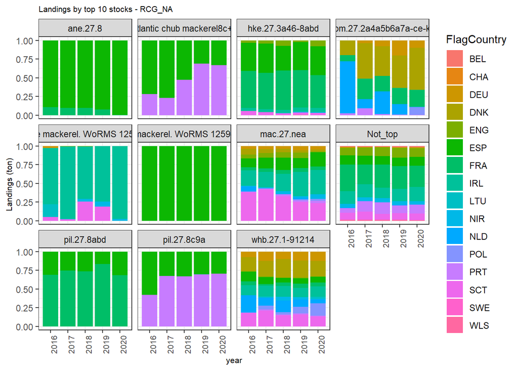